# Intro to Longitudinal Models, Part I

Emorie D Beck

10. July 2018

# Workspace

## Packages

```r
library(psych)
library(broom)
library(knitr)
library(kableExtra)
library(plyr)
library(tidyverse)
```

## Data

This week, our data are going to (continue to) come from the German Socioeconomic Panel Study (GSOEP). The GSOEP is a longitudinal study of adults in German housesholds. The study has a broad range of variables, but for our purposes we’re just going to use personality ratings, age, and gender from 2005 to 2015.

We need to *reduce* our codebook. Use your codebook from last week, and add new column distinguishing personality items from life event items. We don’t need life events this week, so we won’t work with those.

There are different ways to load it in, but I would recommend using some form of loop, which should do the following:  
1. read in the file for a specific year (e.g. using `haven::read_sav()`). 2. pull the variables from the codebook from that year (e.g. using `select()`). - NOTE: you should pull certain variables, like the person and household IDs for every year.  
3. rename those variables in wide format.  
4. add a column to the data for that year that indexes what year the observation is.  
5. merge the data from that year with previous years.

For help with this, see https://emoriebeck.github.io/R-tutorials/purrr/. I’ll give you a `purrr` solution later in the week.

Once you’ve got the codebook, we should be ready to go.

```r
# wd <- "https://github.com/emoriebeck/R-tutorials/blob/master/RA_Files/Week_5_Logistic_Regression"
wd <- "~/Documents/Github/R-tutorials/RA_Files/Week_5_Logistic_Regression"
# load your codebook
# destfile <- "Codebook_EDB.xlsx"
# curl::curl_download(sprintf("%s/Codebook_EDB.xlsx?raw=true", wd), destfile)
destfile <- sprintf("%s/Codebook_EDB.xlsx", wd)
codebook <- readxl::read_excel(destfile) %>%
  mutate(Item = stringr::str_to_lower(Item)) %>%
  filter(class != "group")
```

```r
all.old.cols <- (codebook %>% filter(class == "proc" & Year == 0))$Item
all.new.cols <- (codebook %>% filter(class == "proc" & Year == "0"))$new_name

# create short function to read in separate files for each wave
read_fun <- function(file, year){
  print(year)
  old.names <- (codebook %>% filter(Year == year & class %in% c("group", "predictor", "proc")))$Item
  new.names <- (codebook %>% filter(Year == year & class %in% c("group", "predictor", "proc")))$new_name
  # l.file <- url(sprintf("%s/data/%sp.sav?raw=true", wd, file))
  l.file <- sprintf("%s/data/%sp.sav", wd, file)
  z <- haven::read_sav(l.file) %>%
    select(one_of(all.old.cols), one_of(old.names)) %>%
    setNames(c(all.new.cols, new.names))
}

# you need letters, not numbers to index different data files.
# but years will be more useful to index your codebook, so we'll
# put both in our starting data frame. I've filled out this part.
# Now you just need to figure out how use that to load the files
# and get the correct variables (one's that repeat year to year)
dat <- tibble(
  Year = as.character(seq(2005, 2015,1)),
  file = c(letters[22:26], paste("b", letters[1:6], sep = ""))) %>%
  mutate(data = map2(file, Year, read_fun)) %>%
  unnest(data)
```

```
## [1] "2005"
## [1] "2006"
## [1] "2007"
## [1] "2008"
## [1] "2009"
## [1] "2010"
## [1] "2011"
## [1] "2012"
## [1] "2013"
## [1] "2014"
## [1] "2015"
```

## Descriptives

Because our data are now longitudinal, we need to split our descriptives by year. Try doing this using the `describeBy()` in the `psych` package.

```r
# run the descriptives and check variable ranges
describeBy(dat, dat$Year)
```

```
##
##  Descriptive statistics by group
## group: 2005
##                vars     n       mean         sd  median    trimmed
## Year*             1 20049    2005.00       0.00    2005    2005.00
## file*             2 20049        NaN         NA      NA        NaN
## PROC_SID          3 20049 2999058.49 2416117.19 2724202 2730252.35
## PROC_household    4 20049  296910.92  244818.56  272884  269538.11
## Dem_DOB           5 20049    1957.61      17.59    1959    1957.96
## Dem_Sex           6 20049       1.52       0.50       2       1.53
## BF_C1             7 20049       6.13       1.19       6       6.34
## BF_E1             8 20049       5.46       1.42       6       5.63
## BF_A1             9 20049       2.91       1.69       3       2.78
## BF_O1            10 20049       4.52       1.53       5       4.60
## BF_N1            11 20049       4.68       1.73       5       4.79
## BF_A2            12 20049       5.47       1.41       6       5.65
## BF_C2            13 20049       2.23       1.56       2       1.98
## BF_E2            14 20049       5.05       1.52       5       5.17
## BF_O2            15 20049       4.06       1.88       4       4.10
## BF_N2            16 20049       3.68       1.77       4       3.67
## BF_C3            17 20049       5.72       1.29       6       5.90
## BF_E3            18 20049       4.07       1.68       4       4.12
## BF_A3            19 20049       5.75       1.20       6       5.90
## BF_O3            20 20049       4.76       1.60       5       4.87
## BF_N3            21 20049       4.51       1.57       5       4.59
##                       mad  min     max   range  skew kurtosis       se
## Year*                0.00 2005    2005       0   NaN      NaN     0.00
## file*                  NA  Inf    -Inf    -Inf    NA       NA       NA
## PROC_SID       3242446.20  201 8263202 8263001  0.73    -0.36 17063.64
## PROC_household  339840.09   27  824984  824957  0.70    -0.41  1729.01
## Dem_DOB             20.76 1909    1988      79 -0.16    -0.82     0.12
## Dem_Sex              0.00    1       2       1 -0.08    -1.99     0.00
## BF_C1                1.48   -1       7       8 -2.50     9.73     0.01
## BF_E1                1.48   -1       7       8 -1.11     1.83     0.01
## BF_A1                1.48   -1       7       8  0.48    -0.65     0.01
## BF_O1                1.48   -1       7       8 -0.61     0.69     0.01
## BF_N1                1.48   -1       7       8 -0.50    -0.35     0.01
## BF_A2                1.48   -1       7       8 -1.25     2.29     0.01
## BF_C2                1.48   -1       7       8  1.13     0.59     0.01
## BF_E2                1.48   -1       7       8 -0.78     0.74     0.01
```

[output cut: 452 more lines]

```
## BF_C1                   NA  Inf     -Inf     -Inf    NA       NA       NA
## BF_E1                   NA  Inf     -Inf     -Inf    NA       NA       NA
## BF_A1                   NA  Inf     -Inf     -Inf    NA       NA       NA
## BF_O1                   NA  Inf     -Inf     -Inf    NA       NA       NA
## BF_N1                   NA  Inf     -Inf     -Inf    NA       NA       NA
## BF_A2                   NA  Inf     -Inf     -Inf    NA       NA       NA
## BF_C2                   NA  Inf     -Inf     -Inf    NA       NA       NA
## BF_E2                   NA  Inf     -Inf     -Inf    NA       NA       NA
## BF_O2                   NA  Inf     -Inf     -Inf    NA       NA       NA
## BF_N2                   NA  Inf     -Inf     -Inf    NA       NA       NA
## BF_C3                   NA  Inf     -Inf     -Inf    NA       NA       NA
## BF_E3                   NA  Inf     -Inf     -Inf    NA       NA       NA
## BF_A3                   NA  Inf     -Inf     -Inf    NA       NA       NA
## BF_O3                   NA  Inf     -Inf     -Inf    NA       NA       NA
## BF_N3                   NA  Inf     -Inf     -Inf    NA       NA       NA
```

## Check Missings

How are missings coded in this data set? Do we need to make any changes to how they are coded?

```r
# You should have noted some variables that needed "scrubbed" (changed to missing)
# change those to NA using your preferred method
dat <- dat %>% mutate_all(funs(mapvalues(., seq(-1,-7,-1), rep(NA,7), warn_missing = F)))
```

## Recode Variables

```r
# You should have your keys. Reverse code the items that need reverse coded.
keys     <- codebook$rev_code[codebook$rev_code == -1]
items    <- codebook$new_name[codebook$rev_code == -1]
dat[,items] <- reverse.code(keys, dat[,items], mini = 1, maxi = 7)

# I'm going to give you this chunk because apparently some people don't know what year they were born
dat <- dat %>%
  group_by(PROC_SID) %>%
  mutate(
    Dem_DOB = max(Dem_DOB, na.rm = T),
    Dem_DOB = ifelse(is.infinite(Dem_DOB) == T, NA, Dem_DOB),
    Dem_Sex = max(Dem_Sex, na.rm = T),
    Dem_Sex = ifelse(is.infinite(Dem_Sex) == T, NA, Dem_Sex)
  )
```

## Create New Variables

For these data, we need to create an age variable. There isn’t one in the data set.v

```r
# create an age variable by subtracting the date of birth from 2005
# change gender to a factor
dat <- dat %>%
  mutate(age = 2005 - Dem_DOB,
         gender = factor(Dem_Sex, levels = c(1,2), labels = c("Male", "Female")))
```

## Create composites

For these data, we have lots of items, so we don’t just want to create composites for the Big 5, we also want to create composites for the facets of each of the Big 5. Use the methods we learned before to do so.

### Personality

```r
pers_dat <- dat %>%
  gather(key = item, value = value, BF_A1:BF_O3, na.rm = T) %>%
  separate(item, c("trait", "item"), -1) %>%
  group_by(trait, PROC_SID, PROC_household, Year, Dem_DOB, age, Dem_Sex, gender) %>%
  summarize(value = mean(value, na.rm = T)) %>%
  spread(key = trait, value = value) %>%
  ungroup() %>%
  mutate(wave = as.numeric(mapvalues(Year, c(2005, 2009, 2013), 0:2)))
```

Unfortunately, to run our models below, we’re going to have to get rid of people who don’t have more than 1 wave of data, so we’ll do that below before we move on.

```r
pers_dat <- pers_dat %>%
  group_by(PROC_SID) %>%
  mutate(n = n()) %>%
  filter(n > 1) %>%
  ungroup()
```

# Longitudinal Models

When we talk about longitudinal models, we can be talking about a bunch of things. Longitdudinal models are really just a superordinate category for several families of models meant for dealing with a problem that is not unique to longitudinal data – **non-independence**. Realistically, you’ve encountered and worked with this before, even if you’ve only taken introductory statistics. If you’ve ever run a paired-samples t-test or a repeated measures ANOVA / MANOVA, then you’ve worked with data with non-independence.

In the simplest case, you may be conducting a paired samples t-test of something like depression scores, where you have two measurements from each person – one pre-treatment and one post-treatment. You can’t run an independent samples t-test here because what you’re really testing is whether depression scores differed pre and post-treatment. But the difference isn’t just averages across the two samples. It is possible to show no mean-level changes in depression even if individuals show changes across the two measures. That’s why, with a paired samples t-test, we’re actually testing if the average difference between each person’s pre- and post-treatment scores differ from 0 (no change). This is basically because each person is not independent of (i.e. is dependent on) him- or herself. But by looking at the difference, we’re accounting for differences at baseline and looking at average change.

With longitudinal modeling, we are really just extending this case to more waves and also introducing new methods for examining change in more robust and nuanced ways.

## Hierarchical / Multilevel Models

The framework we are going to use to discuss longitudinal models is called **hierarchical or multilevel modeling** (also sometimes called mixed effects models). We’re going to focus on a specific instance of these models called **multilevel growth models** because there is a specific somewhat stepwise procedure used when the non-independence in the data is due to time.

The idea with MLM/HLM is that we can deal with this non-independence by nesting. With time, we can nest, observations within person, but a classic example of HLM/MLM, is students nested within classrooms and/or classrooms nested within schools. The idea is that we can then look at between group effects and within group effects. With longitudinal data, this means between person and within-person effects. Or group level differences and individual level differences.

Basically, we’re going to take our equation for simple linear regression and extend it. We’re going to use the personality data from the GSOEP to see if there are time associated changes (kind of like when we used age as a predictor of personality a few weeks ago). The model for this would be as follows:

$$Y_{it} = b_0 + b_1*time_t + \epsilon_{it}$$

Note that we now a subscript “t” for time.

We can run this with our data.

```r
nested.mods <- pers_dat %>%
  # move traits to long format for nesting
  gather(key = trait, value = value, BF_A:BF_O, na.rm = T) %>%
  # get rid of inventory tag "BF_" from traits
  mutate(trait = str_remove(trait, "BF_")) %>%
  # group by trait
  group_by(trait) %>%
  # nest the data frame
  nest() %>%
  # run the model and extract the tidy summary
  mutate(model = map(data, ~lm(value ~ wave, data = .)),
         tidy = map(model, broom::tidy))

nested.mods %>%
  # unnest the tidy summary
  unnest(tidy) %>%
  # filter out the slope: "wave"
  filter(term == "wave") %>%
  # format all the model terms to bold if "significant" & round to 2 decimal places
  mutate_at(vars(estimate:p.value),
    funs(ifelse(p.value < .05, sprintf("<strong>%.2f</strong>", .), sprintf("%.2f",.)))) %>%
  # use kable to make an html table
  knitr::kable(., "html", booktabs = T, escape = F) %>%
  kableExtra::kable_styling(full_width = F)
```

| trait | term | estimate | std.error | statistic | p.value |
| --- | --- | --- | --- | --- | --- |
| A | wave | **-0.01** | **0.00** | **-2.60** | **0.01** |
| C | wave | **0.04** | **0.01** | **7.19** | **0.00** |
| E | wave | 0.01 | 0.01 | 0.99 | 0.32 |
| N | wave | **-0.13** | **0.01** | **-14.75** | **0.00** |
| O | wave | -0.01 | 0.01 | -1.78 | 0.08 |

## Random Effects

How do we account for non-independence? We can treat persons as **“random effects.”** There’s a more technical definition that I won’t go into here, but the basic idea is that we can more or less let each person be modeled individually (both intercept and slope) and then join all those individual models back together. This is what we meant when we talked about interindividual differences intraindividual change before. Remember, that looks like this:

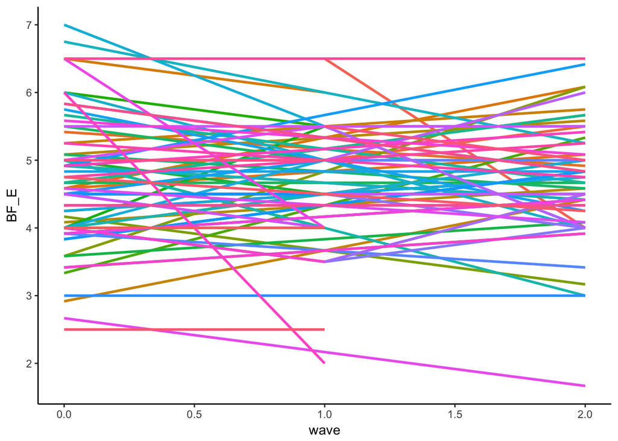

```r
pers_dat %>%
  filter(PROC_SID %in% sample(unique(pers_dat$PROC_SID), 100)) %>%
  ggplot(aes(x = wave, y = BF_E)) +
    geom_smooth(aes(color = factor(PROC_SID), group = PROC_SID), method = "lm", se = F) +
    theme_classic() +
    theme(legend.position = "none")
```

Clearly, people differ both in baseline personality, as well as change in personality. These are our **random effects**, and the variability suggests that we want to model these.

We’re still primarily interested in the **fixed effects** which are the group level / between person effects (average personality and average change in personality), but we also want to account for the dependencies in our data by modeling the **random effects**. In other words, we want to model the group and the individuals.

One way to think about what these MLM/HLM growth models are doing is that they are estimating a model for each person separately, and then estimating group level effects as the averages of the individual models.

```r
pred_fun <- function(fit){
  tibble(wave = seq(0,2,.01)) %>% mutate(pred = predict(fit, newdata = .))
}

nested.ind <- pers_dat %>%
  gather(key = trait, value = value, BF_A:BF_O, na.rm = T) %>%
  mutate(trait = str_remove_all(trait, "BF_")) %>%
  group_by(PROC_SID, trait) %>%
  nest() %>%
  mutate(model = map(data, ~lm(value ~ wave, data = .)),
         tidy = map(model, tidy),
         pred = map(model, pred_fun))

nested.ind %>% unnest(tidy)
```

| PROC_SID | trait | term | estimate | std.error | statistic | p.value |
| --- | --- | --- | --- | --- | --- | --- |
| 602 | A | (Intercept) | 3.666667e+00 | NaN | NaN | NaN |
| 602 | A | wave | 1.000000e+00 | NaN | NaN | NaN |
| 901 | A | (Intercept) | 4.555556e+00 | 2.484520e-01 | 1.833576e+01 | 3.468576e-02 |
| 901 | A | wave | -9.420555e-16 | 1.924501e-01 | -4.895064e-15 | 1.000000e+00 |
| 1501 | A | (Intercept) | 3.111111e+00 | 4.969040e-01 | 6.260990e+00 | 1.008287e-01 |
| 1501 | A | wave | 3.333333e-01 | 3.849002e-01 | 8.660254e-01 | 5.456289e-01 |
| 1601 | A | (Intercept) | 5.833333e+00 | 3.726780e-01 | 1.565248e+01 | 4.061694e-02 |
| 1601 | A | wave | -8.333333e-01 | 2.886751e-01 | -2.886751e+00 | 2.122956e-01 |
| 1602 | A | (Intercept) | 4.666667e+00 | NaN | NaN | NaN |
| 1602 | A | wave | 2.000000e+00 | NaN | NaN | NaN |

[output cut: 9990 more lines]

We can then look calculate the average slopes for each trait and plot:

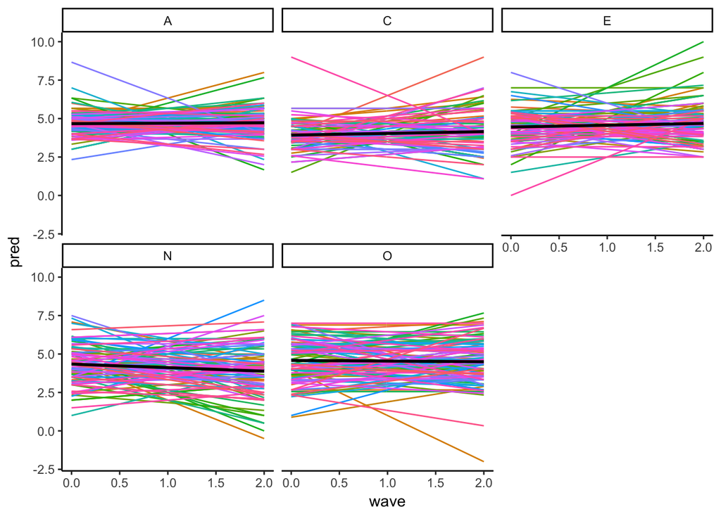

```r
nested.ind %>%
  filter(PROC_SID %in% sample(unique(pers_dat$PROC_SID), 100)) %>%
  unnest(pred) %>%
  ggplot(aes(x = wave, y = pred)) +
    geom_line(aes(color = factor(PROC_SID))) +
    geom_smooth(method = "lm", se = F, color = "black") +
    facet_wrap(~trait) +
    theme_classic() +
    theme(legend.position = "none")
```

The average estimates here are nearly identical to the models we ran before.

The problem with actually estimating the models this way is that the mdoels of a given individual tend to have larger errors associated with them becuase they have fewer observations (per person). Thus, we don’t know the reliability of the average effects when a model is calculated independently. MLM/HLM correct for this by accounting for the lower reliability of individual level effects and “shrinking” the estimates of the individual level effects toward 0 (that is - no effect). Thus, the estimates of MLM/HLM tend to be more conservative than estimates of individual level models.

How do we do this? HLM/MLM accounts for different group and individual level effects by modeling them at different “levels.” Thus, the equations of HLM/MLM also refer to different levels of equations.

The most basic, and the one we’ve worked with thus far, is the **Level 1** equation:

$$Y_{ij} = \beta_{0j} + \epsilon_{ij}$$
Note two key changes to this equation: 1. We know use the notation $\beta$ for the model coefficient, rather than $b$.
2. We have a new subscript, $\beta_{0j}$, rather than $b_0$. This accounts for different estimates of the intercept for different people (individual differences in baseline personality.)

Note that here, we are not yet accounting for time, so the model is really just modeling whether there are individual differences in personality. But the model above doesn’t explicitly show those. That’s where a **Level 2** equation comes in:

$$\beta_{0j} = \gamma_{00} + r_{0j}$$

What does this mean? $\beta_{0j}$ comes from our Level 1 equation above, where j is the subscript for each person, but now we’re breaking it down into two pieces: 1. $\gamma_{00}$ is the fixed term, in this case average personality across the sample. 2. $r_{0j}$ is the random effect, or the difference between the fixed effect term and the actual estimate for a given person. So for example, if $r_{01} = .25$ and $\gamma_{00} = 3$, the estimate $\beta_{01}$ (personality for person 1) would be 3.25.

## The Unconditional Model

In MLM growth models, we always start with what we call an unconditional model, which basically means that we we have only a fixed effect intercept and a random effect intercept. The goal in starting with this is to see if there are individual differences to begin with.

The unconditional model is the one discussed above:  
(Note that we are now using $\hat{Y}$, which subsumes error ($\epsilon_{ij}$) into the model)

Level 1: $\hat{Y}_{ij} = \beta_{0j}$  
Level 2: $\beta_{0j} = \gamma_{00} + r_{0j}$

The question here is basically whether we need the term $r_{0j}$ – that is, are there indivdual differences / dependencies?

Before we talk about what that means, let’s run the models. To do so, we’ll use a package called `lme4`, which is great package with intuitive syntax for running MLM/HLM in `R`. Just like with the `lm()` function, the formulas are in the form `y ~ x`. The one addition we need is something to tell `lme4` what our grouping/nesting variable is and what random effects to include. We do this by adding an additional term on the right hand side (RHS) of the equation: `y ~ x + (1 | grouping)`. The parentheses indicate that we are talking about random effects. The left side of the term in parentheses tells us what random effects to include, while the right hand side tells us what the grouping variable is. A 1 on the LHS means that we want a random intercept (-1 would be no intercept).

```r
# install lme4 if you haven't already
install.packages("lme4")
```

Thus, the corresponding model in our case would be `value ~ 1 + (1 | PROC_SID)`. Both 1’s signal intercepts, with the one outside the parentheses being fixed effect intercept while the one within the parentheses is the random effect intercept.

```r
library(lme4)
# we can keep using our earlier nested data frame.
nested.mods <- nested.mods %>%
  # run the model and get the tidy summaries
  mutate(uc.model = map(data, ~lmer(value ~ 1 + (1 | PROC_SID), data = .)),
         uc.tidy = map(uc.model, broom::tidy))
```

### Intra-Class Correlations

How do we index this? With a measure called **Intraclass correlation** (ICC).

The beauty of MLM is that it allows us to break variance in our data into different components. One piece is unexplained variance (level 1 variance, or the residuals). The second piece is person level variance (level 2 variance). In a normal model, this would fall under level 1, so we wouldn’t be able to separate noise (model error) from person level variance (:( ). A good MLM is one where we have a lot of level 2 / person-level variance.

What this means is relative to the total Level 1 and Level 2 variance in the data, how much of it is at level 2, which is captured in the following equation:

$$ICC = \frac{\tau_{00}^2}{\tau_{00}^2 + \sigma^2}$$
How do we get the ICC of the model? We could manually calculate the ICC, which is a good leanring exercise, but we can also use the `ICC()` function in the `reghelper` package.

```r
install.packages("reghelper")
```

```r
library(reghelper)

(nested.mods <- nested.mods %>%
    mutate(ICC = map_dbl(uc.model, ICC)))
```

| trait | data | model | tidy | uc.model | uc.tidy | ICC |
| --- | --- | --- | --- | --- | --- | --- |
| A |  |  |  |  |  | 0.2889410 |
| C |  |  |  |  |  | 0.3231902 |
| E |  |  |  |  |  | 0.2866569 |
| N |  |  |  |  |  | 0.5043164 |
| O |  |  |  |  |  | 0.5764306 |

```r
# A: 29% of the variance is between people, while the rest is due to within-person variance and random noise
# C: xx% of the variance is between people, while the rest is due to within-person variance and random noise
# E: xx% of the variance is between people, while the rest is due to within-person variance and random noise
# N: xx% of the variance is between people, while the rest is due to within-person variance and random noise
# O: xx% of the variance is between people, while the rest is due to within-person variance and random noise
```

## Adding time

So there seems to be substantial individual differences (between person / level 2 variance). So we want to keep the random intercept and can now move on to the question of time / change. We’ll start by adding a fixed effect of time and work toward adding a random effect. We do it in this order so that we can do model comparisons to tell us whether adding the additional parameters is warranted.

Thus, the form for our equation is now:

**Level 1**: $\hat{Y}_{ij} = \beta_{0j} + \beta_{1j}*time_{ij}$  
We now have 2 Level 2 equations:

**Level 2:**  
$\beta{0j} = \gamma_{00} + r_{0j}$ – fixed effect intercept + random intercept  
$\beta{1j} = \gamma_{10}$ – fixed effect slope + **NO** random slope

In `lme4` terms, this is `value ~ 1 + wave + (1|PROC_SID)`, where the only additional term is the fixed effects term, “wave”.

```r
nested.mods <- nested.mods %>%
  mutate(l.model1 = map(data, ~lmer(value ~ 1 + wave + (1 | PROC_SID), data = .)),
         l.tidy1 = map(l.model1, broom::tidy))
```

Let’s look at the slopes and intercepts of these models

```r
nested.mods %>% unnest(l.tidy1) %>% filter(term == "wave")
```

| trait | ICC | term | estimate | std.error | statistic | group |
| --- | --- | --- | --- | --- | --- | --- |
| A | 0.2889410 | wave | -0.013865300 | 0.003939022 | -3.519985 | fixed |
| C | 0.3231902 | wave | 0.029820460 | 0.004451656 | 6.698733 | fixed |
| E | 0.2866569 | wave | 0.004914506 | 0.004826972 | 1.018134 | fixed |
| N | 0.5043164 | wave | -0.126870494 | 0.006335613 | -20.024974 | fixed |
| O | 0.5764306 | wave | -0.026672117 | 0.005110316 | -5.219269 | fixed |

## Random Slopes and Intercepts

Do we need a random slope? The easiest way to answer this question is by doing a model comparison, but first, we need to add the random slope to the model.

The Level 1 and 2 equations are:  
**Level 1**: $\hat{Y}_{ij} = \beta_{0j} + \beta_{1j}*time_{ij}$  
We now have 2 Level 2 equations:

**Level 2:**  
$\beta{0j} = \gamma_{00} + r_{0j}$ – fixed effect intercept + random intercept  
$\beta{1j} = \gamma_{10} + r_{1j}$ – fixed effect slope + random slope

In `lme4`, the form of the model is `value ~ 1 + wave + (1 + wave | PROC_SID)`, which signals that we have fixed and random intercepts AND slopes.

```r
nested.mods <- nested.mods %>%
  mutate(l.model2 = map(data, ~lmer(value ~ 1 + wave + (1 + wave | PROC_SID), data = .)),
         l.tidy2 = map(l.model2, broom::tidy))
```

Let’s look at the slopes and intercepts of these models

```r
nested.mods %>% unnest(l.tidy2) %>% filter(term == "wave")
```

| trait | ICC | term | estimate | std.error | statistic | group |
| --- | --- | --- | --- | --- | --- | --- |
| A | 0.2889410 | wave | -0.014026645 | 0.003987719 | -3.517460 | fixed |
| C | 0.3231902 | wave | 0.029775342 | 0.004502498 | 6.613072 | fixed |
| E | 0.2866569 | wave | 0.004945906 | 0.004841465 | 1.021572 | fixed |
| N | 0.5043164 | wave | -0.127236868 | 0.006511084 | -19.541581 | fixed |
| O | 0.5764306 | wave | -0.027319463 | 0.005247178 | -5.206506 | fixed |

We do see that our fixed effect estimates did change a little. But did adding the random slopes really add anything?

```r
nested.mods <- nested.mods %>%
  mutate(compare = map2(l.model1, l.model2, anova))

nested.mods$compare
```

```
## [[1]]
## Data: .
## Models:
## .x[[i]]: value ~ 1 + wave + (1 | PROC_SID)
## .y[[i]]: value ~ 1 + wave + (1 + wave | PROC_SID)
##         Df   AIC   BIC logLik deviance  Chisq Chi Df Pr(>Chisq)
## .x[[i]]  4 90677 90711 -45334    90669
## .y[[i]]  6 90670 90722 -45329    90658 10.408      2   0.005494 **
## ---
## Signif. codes:  0 '***' 0.001 '**' 0.01 '*' 0.05 '.' 0.1 ' ' 1
##
## [[2]]
## Data: .
## Models:
## .x[[i]]: value ~ 1 + wave + (1 | PROC_SID)
## .y[[i]]: value ~ 1 + wave + (1 + wave | PROC_SID)
##         Df    AIC    BIC logLik deviance  Chisq Chi Df Pr(>Chisq)
## .x[[i]]  4 102048 102082 -51020   102040
## .y[[i]]  6 102009 102061 -50998   101997 42.734      2  5.254e-10 ***
## ---
## Signif. codes:  0 '***' 0.001 '**' 0.01 '*' 0.05 '.' 0.1 ' ' 1
##
## [[3]]
## Data: .
## Models:
## .x[[i]]: value ~ 1 + wave + (1 | PROC_SID)
## .y[[i]]: value ~ 1 + wave + (1 + wave | PROC_SID)
##         Df    AIC    BIC logLik deviance  Chisq Chi Df Pr(>Chisq)
## .x[[i]]  4 107708 107742 -53850   107700
## .y[[i]]  6 107708 107760 -53848   107696 3.3576      2     0.1866
##
## [[4]]
## Data: .
## Models:
## .x[[i]]: value ~ 1 + wave + (1 | PROC_SID)
## .y[[i]]: value ~ 1 + wave + (1 + wave | PROC_SID)
##         Df    AIC    BIC logLik deviance  Chisq Chi Df Pr(>Chisq)
## .x[[i]]  4 139002 139036 -69497   138994
## .y[[i]]  6 138965 139016 -69476   138953 41.008      2  1.245e-09 ***
## ---
## Signif. codes:  0 '***' 0.001 '**' 0.01 '*' 0.05 '.' 0.1 ' ' 1
##
## [[5]]
## Data: .
## Models:
## .x[[i]]: value ~ 1 + wave + (1 | PROC_SID)
## .y[[i]]: value ~ 1 + wave + (1 + wave | PROC_SID)
##         Df    AIC    BIC logLik deviance Chisq Chi Df Pr(>Chisq)
## .x[[i]]  4 123830 123865 -61911   123822
## .y[[i]]  6 123796 123848 -61892   123784 38.34      2  4.727e-09 ***
## ---
## Signif. codes:  0 '***' 0.001 '**' 0.01 '*' 0.05 '.' 0.1 ' ' 1
```

Looks like random slopes added to all the models but Extraversion, indicating that there were significant interindividual differences in intraindividual personality change for A, C, N, and O.

What does it look like when we add random intercept and slopes to our models?

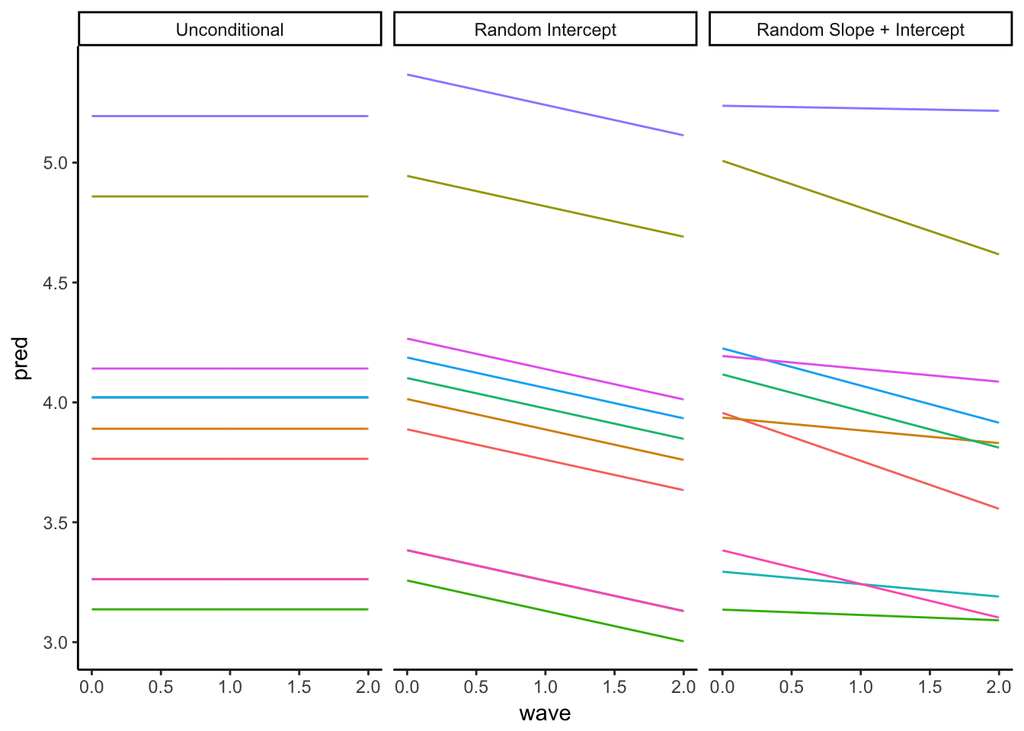

```r
# get a subset of subjects to get predictions for
subs <- sample(unique(pers_dat$PROC_SID), 10)
pred_fun <- function(fit){
  crossing(PROC_SID = subs,
           wave = seq(0, 2, .01)) %>%
    mutate(pred = predict(fit, newdata = .))
}

nested.mods %>%
  # select the models
  select(trait, uc.model, l.model1, l.model2) %>%
  # gather the models
  gather(key = type, value = model, -trait) %>%
  # run the prediciton function on the models
  mutate(pred = map(model, pred_fun)) %>%
  # unnest the results
  unnest(pred) %>%
  # recode the names of the models to make more sense
  mutate(type = factor(mapvalues(type, c("uc.model", "l.model1", "l.model2"),
    c("Unconditional", "Random Intercept", "Random Slope + Intercept")),
    c("Unconditional", "Random Intercept", "Random Slope + Intercept"))) %>%
  # keep only N for demonstrative purposes
  filter(trait == "N") %>%
  # plot the results
  ggplot(aes(x = wave, y = pred, color = factor(PROC_SID))) +
    geom_line() +
    # scale_y_continuous(limits = c(1,7), breaks = seq(1,7,2)) +
    facet_wrap(~type, nrow = 1) +
    theme_classic() +
    theme(legend.position = "none")
```

## Interpretation

Now that we’ve got all the components, let’s walk through the `summary()` of an lme4 growth model.

```r
summary(nested.mods$l.model2[[1]])
```

```
## Linear mixed model fit by REML ['lmerMod']
## Formula: value ~ 1 + wave + (1 + wave | PROC_SID)
##    Data: .
##
## REML criterion at convergence: 90676.7
##
## Scaled residuals:
##     Min      1Q  Median      3Q     Max
## -5.8079 -0.5016  0.0170  0.5152  3.8205
##
## Random effects:
##  Groups   Name        Variance Std.Dev. Corr
##  PROC_SID (Intercept) 0.16027  0.4003
##           wave        0.01001  0.1001   -0.16
##  Residual             0.37017  0.6084
## Number of obs: 42289, groups:  PROC_SID, 16384
##
## Fixed effects:
##              Estimate Std. Error t value
## (Intercept)  4.747177   0.005639   841.8
## wave        -0.014027   0.003988    -3.5
##
## Correlation of Fixed Effects:
##      (Intr)
## wave -0.645
```

### Fixed Effects

Start by looking at the part that says “Fixed effects”. This will be most familiar to you and easy to interpret. These are simply the population level (average) effects. In this case we have:

**wave**: The average change in personality for each new wave of data was -.01.

Where are the p-values? Well, these don’t really make sense with MLM/HLM for reasons we don’t need to get into. Instead, it’s better to talk about these in terms of effect size. One way of doing this is by looking at the t-value section, remembering that anything beyond a t of about +/-2 will be “significant” in most cases although there are exceptions to this. The second (arguably better) way is to use confidence intervals, which we’ll get to later.

### Random Effects

The random effects are your individual differences. This section will give you variance estimates of the level 1 and 2 (random effect) variances.

The estimates in the “Groups” PROC_SID are the level 2 random effects. In other words, if we were to extract the level 1 residuals or the level 2 random effects ($r_{0j}$ and $r_{1j}$) and find their variance (old school style, like you learned in intro stats), these would be your variance estimates. The variance of the random intercepts is $\tau_{00}^2$ (0 = intercept), while the variance of the random slopes is $\tau_{11}^2$ (1 = slope). This also gives us a standard deviation, which if you remember, tells us something about the precision of the estimate.

The estimates in the “Residual” section are the Level 1 residuals. So this would be found by extracting the residuals of the model (e.g. using the `resid()` function) and finding their variance. Ideally this value is small, which indicates that most people don’t differ much from the model.

The only column we haven’t discussed in the “Corr” column. In our model, we (implicitly) specified that we not only wanted to model the level 2 variances but also the correlation between level 2 variables, which in this case, means the correlation between random slopes and intercepts. A positive correlation would mean that people with higher scores at baseline tended to show increases in personality over time, while a negative correlation would mean that people with lower scores at baseline tended to show increases. Sometimes we might want to remove this correlation, but that’s a topic for a later time.

### Scaled Residuals

The scaled residuals can tell you about how your level 1 residuals are distributed. Remember that we want these to be normally distributed (in an ideal world). You can check these out and see if the estimates seem symmetrical. This isn’t a section of primary importance, but it’s good to check out.

### Correlation of Fixed Effects:

(I think this is the corrected correlation between wave and the outcome?)

## Confidence Intervals

When we work with multilevel models, the frequentist statistics through which we derive p values become more complicated and can be difficult to interpret. Thus, we generally use confidence intervals to help us interpret the results.

In the general case, confidence intervals are defined as:

$$CI_{95} = \bar{X} \pm \Bigg[ t_{.975, df = N-1} \frac{\hat{\sigma}}{\sqrt{N}} \Bigg]$$

Where $\frac{\hat{\sigma}}{\sqrt{N}}$ is the standard error of the estimate.

When we use a multilevel model, we need to use a different estimation procedure to estimate the confidence intervals. The two most popular are profile likelihood estimation and through bootstrapping. We’re going to focus on bootstrapping. Bootstrapping, in and of itself, is an active area of investigation. But the basic idea is that the more times we can sample with replacement from our data without influencing the parameter estimates, the more stable the parameter is estimated. So essentially, we sample with replacement from our data (each time pulling the same number of samples as are actually in our dataset) many times and estimate the model. Then we average together the estimates. The confidence intervals will be based on the variability of those estimates.

In R, this is quite simple to do, using the `confint()` function. We just specify the method (“boot”) and nsim arguments. We’re going to set nsim to 10, which is bad (typically we want to do at least 1000, but that can take a lot of time).

```r
nested.mods <- nested.mods %>%
  mutate(l.CI2 = map(l.model2, ~confint(., method = "boot", nsim = 10)))

nested.mods$l.CI2
```

```
## [[1]]
##                   2.5 %       97.5 %
## .sig01       0.38085068  0.412207915
## .sig02      -0.25845541  0.159114150
## .sig03       0.04904758  0.143107883
## .sigma       0.60111675  0.614878753
## (Intercept)  4.73932238  4.754891004
## wave        -0.02079774 -0.007390578
##
## [[2]]
##                   2.5 %     97.5 %
## .sig01       0.44369691 0.46916012
## .sig02      -0.02444077 0.27271373
## .sig03       0.08460025 0.14897096
## .sigma       0.67819638 0.69223893
## (Intercept)  4.02517829 4.04435447
## wave         0.02407018 0.03831923
##
## [[3]]
##                    2.5 %       97.5 %
## .sig01       0.478951660  0.517793882
## .sig02      -1.000000000 -0.001872791
## .sig03       0.018760434  0.132086850
## .sigma       0.740307886  0.757880993
## (Intercept)  4.566291915  4.606607057
## wave        -0.004375837  0.009629476
##
## [[4]]
##                  2.5 %     97.5 %
## .sig01       1.0035136  1.0464239
## .sig02      -0.2655299 -0.1974349
## .sig03       0.2126381  0.2558500
## .sigma       0.9398984  0.9610050
## (Intercept)  4.1690904  4.2072780
## wave        -0.1371569 -0.1112062
##
## [[5]]
##                   2.5 %      97.5 %
## .sig01       0.93390502  0.95322156
## .sig02      -0.25955566 -0.19689847
## .sig03       0.16528788  0.21702764
## .sigma       0.75546486  0.76978855
## (Intercept)  4.46269254  4.49750325
## wave        -0.03444965 -0.01525039
```

## Helper Functions

There are a number of helper functions meant to help you work with `lme4` objects. I’m going to outline them below:

### `fixef()`

`fixef()` prints the fixed effect results of the model as a vector.

```r
fixef(nested.mods$l.model2[[1]])
```

```
## (Intercept)        wave
##  4.74717746 -0.01402665
```

### `vcov()`

`vcov()` prints the variance-covariance matrix of the fixed effects as a class “dpoMatrix”.

```r
vcov(nested.mods$l.model2[[1]])
```

```
## 2 x 2 Matrix of class "dpoMatrix"
##               (Intercept)          wave
## (Intercept)  3.180254e-05 -1.451053e-05
## wave        -1.451053e-05  1.590191e-05
```

### `ranef()`

`ranef()` prints the random components of the model (e.g. $r_{0j}$ and $r_{1j}$). Note that these are **not** the estimated slopes and intercepts for each person, but the deviations from the fixed effect slopes and intercepts.

```r
head(ranef(nested.mods$l.model2[[1]])[[1]])
```

|  | (Intercept) | wave |
| --- | --- | --- |
| 602 | -0.27155069 | 0.015789372 |
| 901 | -0.09798922 | -0.001466131 |
| 1501 | -0.72158559 | 0.001907661 |
| 1601 | 0.18147676 | -0.038578696 |
| 1602 | 0.41073718 | 0.023198498 |
| 2301 | 0.34996726 | -0.017451804 |

### `coef()`

`coef()` prints the random slopes and intercepts of the model (e.g. $\beta_{0j} = \gamma_{00} + r_{0j}$ and $\beta_{1j} = \gamma_{10} + r_{1j}$). Note these are the estimated and slopes for each person.

```r
head(coef(nested.mods$l.model2[[1]])[[1]])
```

|  | (Intercept) | wave |
| --- | --- | --- |
| 602 | 4.475627 | 0.001762726 |
| 901 | 4.649188 | -0.015492777 |
| 1501 | 4.025592 | -0.012118985 |
| 1601 | 4.928654 | -0.052605342 |
| 1602 | 5.157915 | 0.009171852 |
| 2301 | 5.097145 | -0.031478450 |

### `VarCorr()`

`VarCorr()` prints the same summary of the random effects you get through the `summary()` command, except that the variances are in standard deviations ($sd = \sqrt{var}$), rather than in variance terms. In other words, it prints the standard deviation of the empirical bayes estimates of the random effects (level 2 effects) and level 1 residuals, as well as the correlation between the random effects.

```r
VarCorr(nested.mods$l.model2[[1]])
```

```
##  Groups   Name        Std.Dev. Corr
##  PROC_SID (Intercept) 0.40033
##           wave        0.10006  -0.159
##  Residual             0.60842
```

### `confint.merMod()`

`confint.merMod()` prints the confidence intervals of the bootstrapped models. It can be tricky to join these back up with the estimates, but I’ll provide a method for doing that below. Again, using way too few simulations here for time reasons.

```r
confint.merMod(nested.mods$l.model2[[1]], method = "boot", nsim = 10)
```

```
##                   2.5 %      97.5 %
## .sig01       0.38326227  0.41747489
## .sig02      -0.26074318 -0.02254583
## .sig03       0.06655778  0.12902313
## .sigma       0.60015562  0.61617377
## (Intercept)  4.74423358  4.75486353
## wave        -0.01869536 -0.01019691
```

### `ICC()`

ICC prints the ICC of the model. Note that this should only be run with the unconditional model or it’s weird to interpret.

```r
reghelper::ICC(nested.mods$l.model2[[1]])
```

```
## [1] 0.3150674
```

## Plotting Results

Plotting the results of (the fixed effects of) these models isn’t too bad. When we just want to plot the fixed effects, we just have to specify the range of the values since we don’t have any other predictors. We do, however, need to specify an additional argument in the predict function. By setting re.form to NA, we tell predict that we just want the fixed effects. If we don’t do this, then the predict function will insist you provide a grouping variable (which as a reminder is PROC_SID for us) and will estimate predicted values separately for each group.

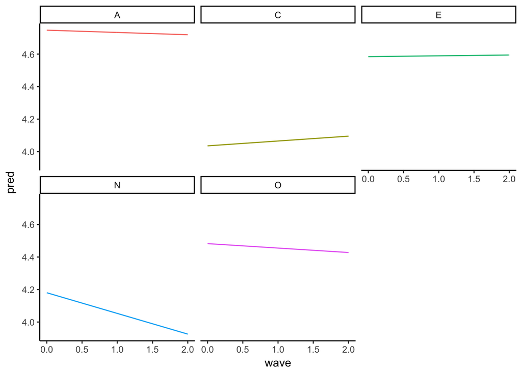

```r
pred_fun <- function(fit){
  tibble(wave = seq(0,2,.01)) %>% mutate(pred = predict(fit, newdata = ., re.form = NA))
}

nested.mods %>%
  # get predicted values
  mutate(l.pred2 = map(l.model2, pred_fun)) %>%
  # unnest predicted values
  unnest(l.pred2) %>%
  # call ggplot
  ggplot(aes(x = wave, y = pred, color = trait)) +
  # draw the lines
  geom_line() +
  # create facets
  facet_wrap(~trait) +
  # set the theme
  theme_classic() +
  # remove the legend
  theme(legend.position = "none")
```

Note, we still need confidence bands around the lines to tell us about uncertainty of the estimate. We’ll tackle that next week.

## Creating Tables

Creating tables is an art, and there are lots of pieces you might want with HLM/MLM. To that end, I’ve written a function that can deal with MLM models. You can work through it if you like, but it’s basically just meant to join together disparate info from different parts of the model (including confidence intervals) into a unified table. Note that if you decide to use this for “real” models, you should modify the function to up the number of simulation for the confidence intervals.

```r
table_fun <- function(model){
  fixed <- broom::tidy(model) %>% filter(group == "fixed") %>%
    select(term, estimate)
  ## add random effects ##
  rand <- VarCorr(model)[[1]]
  if(nrow(rand) > 1){
  rand <- rand[1:nrow(rand), 1:nrow(rand)]
  }
  colnames(rand)[colnames(rand) == "(Intercept)"] <- "Intercept"
  rownames(rand)[rownames(rand) == "(Intercept)"] <- "Intercept"
  vars <- rownames(rand)
  rand[upper.tri(rand)] <- NA
  rand <- data.frame(rand) %>% mutate(var1 = rownames(.)) %>%
    gather(key = var2, value = estimate, -var1, na.rm = T) %>%
    mutate(var1 = mapvalues(var1, vars, 0:(length(vars)-1)),
           var2 = mapvalues(var2, unique(var2), 0:(length(vars)-1))) %>%
    filter(var1 == var2) %>%
    unite(var, var1, var2, sep = "") %>%
    mutate(var = sprintf("$\\tau_{%s}$", var))
  ## get confidence intervals ##
  CI <- data.frame(confint.merMod(model, method = "boot", nsim = 10, oldNames = F)) %>%
    mutate(term = rownames(.)) %>% setNames(c("lower", "upper", "term"))

  CI %>% filter(term == "sigma") %>%
    mutate(estimate = sigma(model),
           term = "$\\sigma^2$",
           type = "Residuals")

  ## Get ICC & R2 values ##
  R2 <- MuMIn::r.squaredGLMM(model)

  ## format the fixed effects
  fixed <- fixed %>% left_join(CI %>% filter(!grepl(".sig", term))) %>%
    mutate(type = "Fixed Parts", term = str_remove_all(term, "[()]"))

  rand <- rand %>%
    left_join(
      CI %>% filter(grepl("sd", term)) %>%
        mutate(lower = lower^2, upper = upper^2,
               var = mapvalues(term, unique(term), 0:(length(unique(term))-1)),
               var = sprintf("$\\tau_{%s%s}$", var, var)) %>% select(-term)) %>%
    mutate(type = "Random Parts") %>% rename(term = var)

  mod_terms <- tribble(
    ~term, ~estimate, ~type,
    # "ICC", ICC, "Model Terms",
    "$R^2_m$", R2[1], "Model Terms",
    "$R^2_c$", R2[2], "Model Terms"
  )

  tab <- fixed %>%
    full_join(rand) %>%
    mutate(CI = sprintf("[%.2f, %.2f]", lower, upper)) %>%
    select(-lower, -upper) %>%
    full_join(mod_terms) %>%
    mutate(estimate = sprintf("%.2f", estimate)) %>%
    dplyr::rename(b = estimate) %>%
    select(type, everything())
  return(tab)
}
```

We can use this function for the models in our table:

```r
nested.mods <- nested.mods %>% mutate(l.tab2 = map(l.model2, table_fun))

nested.mods %>% unnest(l.tab2)
```

| trait | ICC | type | term | b | CI |
| --- | --- | --- | --- | --- | --- |
| A | 0.2889410 | Fixed Parts | Intercept | 4.75 | [4.74, 4.75] |
| A | 0.2889410 | Fixed Parts | wave | -0.01 | [-0.02, -0.01] |
| A | 0.2889410 | Random Parts | $\\tau_{00}$ | 0.16 | [0.15, 0.17] |
| A | 0.2889410 | Random Parts | $\\tau_{11}$ | 0.01 | [0.00, 0.02] |
| A | 0.2889410 | Model Terms | $R^2_m$ | 0.00 | NA |
| A | 0.2889410 | Model Terms | $R^2_c$ | 0.31 | NA |
| C | 0.3231902 | Fixed Parts | Intercept | 4.04 | [4.02, 4.05] |
| C | 0.3231902 | Fixed Parts | wave | 0.03 | [0.03, 0.04] |
| C | 0.3231902 | Random Parts | $\\tau_{00}$ | 0.21 | [0.20, 0.22] |
| C | 0.3231902 | Random Parts | $\\tau_{11}$ | 0.01 | [0.01, 0.02] |

[output cut: 20 more lines]

This function does most of the heavy lifting for us, but we will need to reorganize. With 5 traits, I usually do something like the following:

```r
(tab <- nested.mods %>%
# unnest the table results
unnest(l.tab2) %>%
# remove the ICC
select(-ICC) %>%
# make the b and CI long for reshaping
gather(key = est, value = value, b, CI, na.rm = T) %>%
# create a new variable joining together the type of term (b, CI) and trait
unite(tmp, trait, est, sep = ".") %>%
# change to wide format
spread(key = tmp, value = value) %>%
# factor the rows to control rearrangement
mutate(type = factor(type, levels = c("Fixed Parts", "Random Parts", "Model Terms"))) %>%
# rearrange the variables
arrange(type))
```

| type | term | A.b | A.CI | C.b | C.CI | E.b | E.CI | N.b | N.CI | O.b | O.CI |
| --- | --- | --- | --- | --- | --- | --- | --- | --- | --- | --- | --- |
| Fixed Parts | Intercept | 4.75 | [4.74, 4.75] | 4.04 | [4.02, 4.05] | 4.58 | [4.57, 4.60] | 4.18 | [4.16, 4.20] | 4.48 | [4.46, 4.50] |
| Fixed Parts | wave | -0.01 | [-0.02, -0.01] | 0.03 | [0.03, 0.04] | 0.00 | [-0.01, 0.01] | -0.13 | [-0.14, -0.12] | -0.03 | [-0.04, -0.02] |
| Random Parts | $\\tau_{00}$ | 0.16 | [0.15, 0.17] | 0.21 | [0.20, 0.22] | 0.24 | [0.23, 0.26] | 1.07 | [1.03, 1.09] | 0.89 | [0.87, 0.95] |
| Random Parts | $\\tau_{11}$ | 0.01 | [0.00, 0.02] | 0.01 | [0.01, 0.02] | 0.00 | [0.00, 0.01] | 0.06 | [0.04, 0.07] | 0.04 | [0.02, 0.05] |
| Model Terms | $R^2_c$ | 0.31 | NA | 0.34 | NA | 0.29 | NA | 0.54 | NA | 0.60 | NA |
| Model Terms | $R^2_m$ | 0.00 | NA | 0.00 | NA | 0.00 | NA | 0.01 | NA | 0.00 | NA |

Then, we can use this with `knitr::kable()` and the `kableExtra` package to create a nicely formatted table output.

```r
options(knitr.kable.NA = '') # make NAs print as blank
tab %>%
  kable(., "html", booktabs = T, escape = F) %>%
  kable_styling(full_width = F)
```

| type | term | A.b | A.CI | C.b | C.CI | E.b | E.CI | N.b | N.CI | O.b | O.CI |
| --- | --- | --- | --- | --- | --- | --- | --- | --- | --- | --- | --- |
| Fixed Parts | Intercept | 4.75 | [4.74, 4.75] | 4.04 | [4.02, 4.05] | 4.58 | [4.57, 4.60] | 4.18 | [4.16, 4.20] | 4.48 | [4.46, 4.50] |
| Fixed Parts | wave | -0.01 | [-0.02, -0.01] | 0.03 | [0.03, 0.04] | 0.00 | [-0.01, 0.01] | -0.13 | [-0.14, -0.12] | -0.03 | [-0.04, -0.02] |
| Random Parts | $\tau_{00}$ | 0.16 | [0.15, 0.17] | 0.21 | [0.20, 0.22] | 0.24 | [0.23, 0.26] | 1.07 | [1.03, 1.09] | 0.89 | [0.87, 0.95] |
| Random Parts | $\tau_{11}$ | 0.01 | [0.00, 0.02] | 0.01 | [0.01, 0.02] | 0.00 | [0.00, 0.01] | 0.06 | [0.04, 0.07] | 0.04 | [0.02, 0.05] |
| Model Terms | $R^2_c$ | 0.31 |  | 0.34 |  | 0.29 |  | 0.54 |  | 0.60 |  |
| Model Terms | $R^2_m$ | 0.00 |  | 0.00 |  | 0.00 |  | 0.01 |  | 0.00 |  |

This is kind of ugly and not something we would include in a publication, but we can use some functions from the `knitr` and `kableExtra` packages that will allow us to format these tables easily. Here’s a few we’ll use:

`knitr::kable()`: this is a super useful function. I’m going to note a few of the arguments that make this super flexible:  
- format = c(“html”, “latex”). This argument should be set according to how to plan to knit your document. “html” when you are knitting to html and “latex” when you are knitting to PDF or Word.  
- booktabs = TRUE. As a practice, I always set booktabs to TRUE. It’s just a type of table.  
- col.names = c(). Set this to set the names of the column. This is especially useful when you need to have spaces in your column names or need to have column names which repeat. Data frames don’t like it when you have these, so we set them here.  
- align = c(). Set the alignment of the columns. This should be a vector of “l”, “c”, and “r”’s the same length as the number of columns in your data frame.  
- caption = “”. Give a title to your table.

`kableExtra::kable_styling()`: this function let’s you set some of the styling for the table. The main argument you want to set here is full_width = FALSE.

`kableExtra::add_header_above()`: if you want superordinate headers, use this function. So, for example, in the table below, we have two of the same columns for each of the Big 5, so we can set the superordinate headers for each of these to do that.

`kableExtra::group_rows()`: We’ll talk about this one next week, but I wanted to stick it on your radar.

```r
tab %>%
  kable(., "html", booktabs = T, escape = F,
        # set the column names
        col.names = c("", "Term", rep(c("b", "CI"), times = 5)),
        # set column alignment
        align = c("l", "l", rep("c", 10))) %>%
  kable_styling(full_width = F) %>%
  # create floating header above
  add_header_above(c(" " = 2, "Agreeableness" = 2, "Conscientiousness" = 2,
                    "Extraversion" = 2, "Neuroticism" = 2, "Openness" = 2))
```

|  | Term | Agreeableness b | Agreeableness CI | Conscientiousness b | Conscientiousness CI | Extraversion b | Extraversion CI | Neuroticism b | Neuroticism CI | Openness b | Openness CI |
| --- | --- | --- | --- | --- | --- | --- | --- | --- | --- | --- | --- |
| Fixed Parts | Intercept | 4.75 | [4.74, 4.75] | 4.04 | [4.02, 4.05] | 4.58 | [4.57, 4.60] | 4.18 | [4.16, 4.20] | 4.48 | [4.46, 4.50] |
| Fixed Parts | wave | -0.01 | [-0.02, -0.01] | 0.03 | [0.03, 0.04] | 0.00 | [-0.01, 0.01] | -0.13 | [-0.14, -0.12] | -0.03 | [-0.04, -0.02] |
| Random Parts | $\tau_{00}$ | 0.16 | [0.15, 0.17] | 0.21 | [0.20, 0.22] | 0.24 | [0.23, 0.26] | 1.07 | [1.03, 1.09] | 0.89 | [0.87, 0.95] |
| Random Parts | $\tau_{11}$ | 0.01 | [0.00, 0.02] | 0.01 | [0.01, 0.02] | 0.00 | [0.00, 0.01] | 0.06 | [0.04, 0.07] | 0.04 | [0.02, 0.05] |
| Model Terms | $R^2_c$ | 0.31 |  | 0.34 |  | 0.29 |  | 0.54 |  | 0.60 |  |
| Model Terms | $R^2_m$ | 0.00 |  | 0.00 |  | 0.00 |  | 0.01 |  | 0.00 |  |

## Level 2 Variances – Individual Differences

Thus far, we’ve talked about Level 2 variances but not about precisely what they are. Level 2 variances are really important because they are, to some degree, what MLM/HLM buy us. They are allowing us to parse the total variance in the data set to different sources.

Remember – in simple linear regression, our model comes in the form
$$Y_{i} = b_0 + b_1*X_{1i} + ... + b_p*X_{pi} + \epsilon_{i}$$
where $p$ is the number of predictors, the $i$ subscript denotes an individual observation, and $\epsilon_i$ is the residual for each person. In this case, the residuals are just the unexplained variance.

In MLM/HLM, our model is in the form:  
Level 1: $Y_{ij} = \beta_{0j} + \beta_{1j}*X_{1j} + ... + \beta_{pj}*X_{pj} + \epsilon_{ij}$  
Level 2:  
$\beta_{0j} = \gamma_{00} + r_{0j}$  
$\beta_{1j} = \gamma_{10} + r_{1j}$  
…  
$\beta_{pj} = \gamma_{p0} + r_{pj}$

The terms, $r_{0j}$ to $r_{pj}$ are also residuals, indexing specifically how much the model misses each person on each of the different Level 1 predictors. The idea is basically that the bigger the level 2 residual terms, the worse we are capturing someone on average. In growth models, we use this to our advantage because they tell us something about individual differences in mean levels and change, but often we want to reduce these as much as possible by adding predictors that explain the mean levels or patterns of change.

But the trick is that we only have these variances when we add the random effects. So, for example, in the model in which we had a random intercept but no random slope, the variance in change from the average slope at the person level was subsumed into the $\epsilon_{ij}$ term (roughly, in practice adding additional level 1 and 2 predictors can influence this). Thus, we can’t really distinguish where that noise is coming from when there isn’t a random effect. Does that mean we should just add the random effects we can? No, because if the random effect isn’t really doing anything (deviations from the average effect are quite small), then the level 2 variances will be small and can be dropped. And we can compare models with and without a specific random effect to test whether we can add or drop terms.

Remember from the summary output that, by default, we not only had the variances of each of the random terms but also the correlations among them (e.g. $cor(r_{0j}, r_{1j})$). Because of this, when we talk about Level 2 effects, we often think of them in matrix form, which is called the tau ($\tau$) matrix.

The number of rows and columns of the tau matrix will be equal to the number of random effects included in the model. So, if we have a random slope and intercept, then the tau matrix would be 2x2.

$$\begin{bmatrix}
\tau_{00}^2 & \tau_{01}\\
\tau_{10} & \tau_{11}^2\\
\end{bmatrix}$$

Or, in the more general form for $r$ random effects.

$$\begin{bmatrix}
\tau_{00}^2 & \tau_{01} & ... & \tau_{0r}\\
\tau_{10} & \tau_{11}^2 & ... & \tau_{1r}\\
... & ... & ... & ... \\
\tau_{r0} & \tau_{r1} & ... & \tau_{rr}^2
\end{bmatrix}$$

Why is this important to note? Well, remember from multiple regression that more parameters will always explain more variance, but that we have to balance the number of parameters we add such that they actually add something useful to the model. Every time we add a random effect, we are not adding just 1 parameter because we are adding one variance for that random effect ($\tau_{rr}^2$) as well as covariances between that random effect and all others.

So, for example, if we had 2 random effects, we would be estimating 3 level 2 paramters in the tau matrix. But if we add 1 more, we will be estimating a total of 6 level 2 parameters in the tau matrix. In other words, for each additional random effect we add to the model, we will be adding additional paramters equal to the number total random effects in the (so if we had 1 and 1 more, we would be adding 1 + 1 = 2 new parameters, while if we had 2 and added 1, we would be adding 2 + 1 = 3 paramters for a total of 6).